# Testing Bias Correction

Adam Griffin; UKCEH

17/11/2020

In this document we analyse the difference between including and excluding the bias correction on gridded data making use of UKCP18 meteorological inputs.

Here the bias correction used is that of Guillod et al. (2018), which has been applied in a pooled approach(using all the RCM members to generate the bias correction factor together) and a seperate approach (seperate correction factors for each RCM)

## Data Exploration

```r
wd <- paste0("//nercwlsmb01/prj/ukscape2.2",
             "/run_gb_hmfg2g_ukcp18rcm12km/outputs/baseline_PEi_198012_201011")

D <- dir(wd, pattern="dmamflow_out.nc", recursive=T, full.names=T)
D_TBC <- D[grepl("T", sapply(D, function(x){strsplit(x,"/")[[1]][9]}))]
D_FBC <- D[grepl("F", sapply(D, function(x){strsplit(x,"/")[[1]][9]}))]

Enc <- paste0("//nercwlsmb01/prj/ukscape2.2",
              "/run_gb_hmfg2g_ukcp18rcm12km/outputs/simobs/dmamflow_out.nc")

rcm_nos <- c(1,4,5,6,7,8,9,10,11,12,13,15)

CATAL <- catalogue()
CATAL <- CATAL[CATAL$`nrfa-mean-flow`,]

statlocs <- read_delim("./catcoords_istat_jstat_01000.txt", delim="\t", col_types=cols(
  gauge = col_double(),
  istat = col_double(),
  jstat = col_double()
))
statlocs$jstat <- statlocs$jstat - 250
```

First we will open the files and see what kind of data it is: predominantly netCDF files.

```r
NCIN <- nc_open(D[1])
print(NCIN)
```

```
## File //nercwlsmb01/prj/ukscape2.2/run_gb_hmfg2g_ukcp18rcm12km/outputs/baseline_PEi_198012_201011/rcm12km_wsnow_wbcF_01_wsaard/dmamflow_out.nc (NC_FORMAT_NETCDF4):
##
##      1 variables (excluding dimension variables):
##         float dmamflow[Easting,Northing,Time]   (Chunking: [700,1000,1])  (Compression: shuffle,level 5)
##             units: m3 s-1
##             standard_name: dmamflow
##             long_name: Annual maxima of daily mean river flow
##             _FillValue: -999
##             missing_value: -999
##
##      3 dimensions:
##         Northing  Size:1000
##             standard_name: Northing
##             axis: Y
##             units: GB National Grid
##         Easting  Size:700
##             standard_name: Easting
##             axis: X
##             units: GB National Grid
##         Time  Size:30   *** is unlimited ***
##             standard_name: Time
##             axis: T
##             units: calendar_year as %Y
##             calendar: 360_day
```

```r
dmamax <- ncvar_get(NCIN, "dmamflow")
nor <- ncvar_get(NCIN, "Northing")
eas <- ncvar_get(NCIN, "Easting")

CATAL <- CATAL[CATAL$northing < 1000000 & CATAL$northing > 0 &
                 CATAL$easting < 700000 & CATAL$easting > 0 &
                 CATAL$id %in% statlocs$gauge,]

print(nrow(CATAL))
```

```
## [1] 1339
```

```r
rn <- which((!is.na(dmamax[,,2])) & (dmamax[,,2] > -1), arr.ind=T)
rn_pos <- cbind(nor[rn[,2]], eas[rn[,1]])

dim(dmamax)
```

```
## [1]  700 1000   30
```

```r
str(dmamax)
```

```
##  num [1:700, 1:1000, 1:30] NA NA NA NA NA NA NA NA NA NA ...
```

```r
summary(dmamax)
```

```
##     Min.  1st Qu.   Median     Mean  3rd Qu.     Max.     NA's
##       -1       -1       -1        6       -1     4559 14380141
```

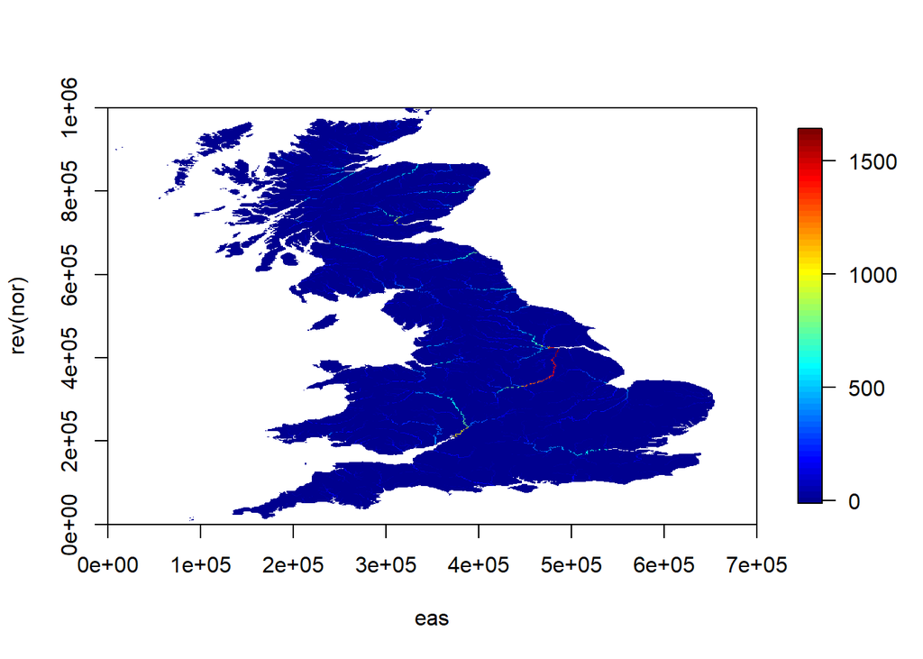

```r
#dmamax[250:260, 80:90,2]
image.plot(x=eas, y=rev(nor), dmamax[,1000:1,2])
```

```r
nc_close(NCIN)
```

Here we have time series of annual maxima based on daily flow for each gridpoint.

We’re going to compare this to the daily mean flow for gauged stations in the UK. Note this is different from the standard AMAX calculations which use instantaneous peak flow to determine flood frequency curves. However, since the G2G outputs are at a daily resolution, this is the most comparable approach.

## DM AMAX Extraction

First we extract the AMAX values from the gauged daily flow from the NRFA API, and the corresponding amax from the relevant gridpoints in the RCM outputs.

```r
am_summ_obs <- data.frame(station=numeric(),
                          year=numeric(),
                          value=numeric())
##### OBS #####
for(k in 1:nrow(CATAL)){
  if(k %% 100 == 0){print(k)}
  stn1 <- CATAL$id[k]

  gdf1 <- gdf(stn1)
  gdf_hyyr <- findHydrolYr(index(gdf1))
  gdf1 <- cbind(as.vector(gdf1), gdf_hyyr)
  colnames(gdf1)[1] <- "gdf"
  suppressMessages({
    gdf2 <- gdf1 %>%
          dplyr::filter(yr >= 1981 & yr <= 2010) %>%
          group_by(yr) %>%
          summarise(value=max(gdf, na.rm=T))
  })
  gdf2$station <- stn1
  am_summ_obs <- rbind(am_summ_obs, gdf2[,c(3,1,2)])
}

rn1 <- matrix(NA, nrow=nrow(CATAL), ncol=2)
for(k in 1:nrow(CATAL)){
  if(k%%100==0){print(k)}
  pos <- c(CATAL$northing[k], CATAL$easting[k])
  rn1[k, ] <- unlist(statlocs[statlocs$gauge==CATAL$id[k], ][2:3], use.names=F)
}

##### SIMOBS #####
colnames(am_summ_obs) <- c("station", "year", "value")

am_sim_obs <- data.frame(station=numeric(),
                         year=numeric(),
                         value=numeric())

NCSIMOBS <- nc_open(Enc)
dmamax_simobs <- ncvar_get(NCSIMOBS, "dmamflow")
for(k in 1:nrow(CATAL)){
  if(k %% 100 == 0){print(k)}
  stn1 <- CATAL$id[k]
  am_k <- dmamax_simobs[rn1[k, 1],rn1[k, 2], ]
  df <-data.frame(station=stn1,
                  year=1980:2010,
                  value=am_k)

  am_sim_obs <- rbind(am_sim_obs, df)
}

#wider version
AM <- dcast(am_summ_obs, station~year, value.var="value")
AMSIM <- dcast(am_sim_obs, station~year, value.var="value")

write_csv(am_summ_obs, "S:/Data/BiasCorrection/am_obs.csv")
write_csv(am_sim_obs,  "S:/Data/BiasCorrection/am_sim_obs.csv")
```

Here we extract the DM AMAX values for all the stations we can, any with a DMF time series on the NRFA. We take the nearest gridpoint to the station as a comparison, and take the annual maxima of the daily mean flow in each year (no accounting for missing data in the DMF at this point.)

```r
am_summ_TBC <- data.frame(rcm=numeric(),
                          station=numeric(),
                          year=numeric(),
                          value=numeric())
am_summ_FBC <- data.frame(rcm=numeric(),
                          station=numeric(),
                          year=numeric(),
                          value=numeric())

#CATAL


##### RCMS #####
for(j in seq_len(length(rcm_nos))){
  for(l in 1:2){
    if(l == 1){
      NCIN <- nc_open(D_TBC[j])
      print(D_TBC[j])
    }else{
      NCIN <- nc_open(D_FBC[j])
      print(D_FBC[j])
    }
    dmamax <- ncvar_get(NCIN, "dmamflow")

    for(k in 1:nrow(CATAL)){
      stn1 <- CATAL$id[k]
      am_k <- dmamax[rn1[k,1],rn1[k,2],]
      df <-data.frame(rcm=rcm_nos[j],
                  station=stn1,
                  year=1981:2010,
                  value=am_k)

      if(l == 1){
        am_summ_TBC <- rbind(am_summ_TBC, df)
      }else{
        am_summ_FBC <- rbind(am_summ_FBC, df)
      }
    }
  }
}
readr::write_csv(x=am_summ_TBC, path="S:/Data/BiasCorrection/am_TBC.csv")
readr::write_csv(x=am_summ_FBC, path="S:/Data/BiasCorrection/am_FBC.csv")
```

## AMAX analysis

We can’t expect the AMAX values to match up between RCMs and the observations, but we can check average differences between the same RCM with and without bias correction (TBC and FBC, respectively), and we can compare GLO fits; we restrict the observed DM AMAX to hydrological years 1981-2010.

```r
am_glo_obs <- data.frame(station=numeric(),
                         reclen=numeric(),
                         loc=numeric(),
                         sca=numeric(),
                         sha=numeric(),
                         QMED=numeric(),
                         Q20=numeric(),
                         Q50=numeric())

am_glo_simobs <- data.frame(station=numeric(),
                         reclen=numeric(),
                         loc=numeric(),
                         sca=numeric(),
                         sha=numeric(),
                         QMED=numeric(),
                         Q20=numeric(),
                         Q50=numeric())

am_glo_TBC <- data.frame(rcm=numeric(),
                         station=numeric(),
                         reclen=numeric(),
                         loc=numeric(),
                         sca=numeric(),
                         sha=numeric(),
                         QMED=numeric(),
                         Q20=numeric(),
                         Q50=numeric())

am_glo_FBC <- data.frame(rcm=numeric(),
                         station=numeric(),
                         reclen=numeric(),
                         loc=numeric(),
                         sca=numeric(),
                         sha=numeric(),
                         QMED=numeric(),
                         Q20=numeric(),
                         Q50=numeric())

qt <- 1 - 1/c(2,20,50)
for(i in 1:nrow(CATAL)){
  if(i %% 100 == 0){print(CATAL$id[i])}
  try({
    am_temp <- am_summ_obs %>% dplyr::filter(station==CATAL$id[i])
    am_glo_obs[i, 1:5] <- c(CATAL$id[i],
                            length(unique(am_temp$year)),
                            parglo(lmoms(am_temp$value))$para)
    am_glo_obs[i, 6:8]  <- quaglo(qt, parglo(lmoms(am_temp$value)))
  }, silent=T)

  try({
    am_temp <- am_sim_obs %>% dplyr::filter(station==CATAL$id[i])
    am_glo_simobs[i, 1:5] <- c(CATAL$id[i],
                               length(unique(am_temp$year)),
                               parglo(lmoms(am_temp$value))$para)
    am_glo_simobs[i,6:8]  <- quaglo(qt, parglo(lmoms(am_temp$value)))
  }, silent=T)

  for(j in 1:length(rcm_nos)){
    try({
    am_temp <- am_summ_TBC %>% dplyr::filter(station==CATAL$id[i] & rcm==rcm_nos[j])
    am_glo_TBC[(i-1)*length(rcm_nos) + j, 1:6] <- c(rcm_nos[j], CATAL$id[i],
                                                    length(unique(am_temp$year)),
                                                    parglo(lmoms(am_temp$value))$para)
    am_glo_TBC[(i-1)*length(rcm_nos) + j, 7:9]  <- quaglo(qt, parglo(lmoms(am_temp$value)))

    am_temp <- am_summ_FBC %>% dplyr::filter(station==CATAL$id[i] & rcm==rcm_nos[j])
    am_glo_FBC[(i-1)*length(rcm_nos) + j, 1:6] <- c(rcm_nos[j], CATAL$id[i],
                                                    length(unique(am_temp$year)),
                                                    parglo(lmoms(am_temp$value))$para)
    am_glo_FBC[(i-1)*length(rcm_nos) + j, 7:9]  <- quaglo(qt, parglo(lmoms(am_temp$value)))
    }, silent=T)
  }
}
write_csv(am_glo_obs, path="S:/Data/BiasCorrection/glo_obs.csv")
write_csv(am_glo_simobs, path="S:/Data/BiasCorrection/glo_simobs.csv")
write_csv(am_glo_TBC, path="S:/Data/BiasCorrection/glo_TBC.csv")
write_csv(am_glo_FBC, path="S:/Data/BiasCorrection/glo_FBC.csv")
```

```r
AM <- dcast(am_summ_obs, station~year, value.var="value")
AMSIM <- dcast(am_sim_obs, station~year, value.var="value")
U_am <- unique(am_summ_obs$station)
U_sim <- unique(am_sim_obs$station)
U_obs <- unique(am_glo_obs$station) #1323
U_tbc <- unique(am_glo_TBC$station) #1511
U_fbc <- unique(am_glo_FBC$station)
CID <- CATAL$id
V <- Reduce(intersect, list(U_am, U_sim, U_obs, U_tbc, U_fbc, CID)) #1322
sapply(list(U_am, U_sim, U_obs, U_tbc, U_fbc, CID, V), length)
```

```
## [1] 1249 1339 1185 1043 1043 1339  947
```

```r
am_glo_simobs <- am_glo_simobs %>% dplyr::filter(station %in% V)
am_glo_obs <-    am_glo_obs %>% dplyr::filter(station %in% V)
am_glo_TBC <-    am_glo_TBC %>% dplyr::filter(station %in% V)
am_glo_FBC <-    am_glo_FBC %>% dplyr::filter(station %in% V)
#am_summ_obs <-   am_summ_obs %>% dplyr::filter(station %in% V)


CATAL0 <- CATAL[CATAL$id %in% V, ] #1402 rows
AM <- AM[AM$station %in% V,] #1402 rows
QM <- apply(AM[,-1], 1,
            function(x){ifelse(!sum(is.na(x))<25, NA, median(x, na.rm=T))})
QM <- cbind(AM$station, QM)

AMSIM <- AMSIM[AMSIM$station %in% V, ]
QS <- apply(AMSIM[,-1], 1,
            function(x){ifelse(!sum(is.na(x))<25, NA, median(x, na.rm=T))})
QS <- cbind(AMSIM$station, QS)

dTBC <- am_glo_TBC %>% group_by(station) %>% summarise(qmed1 = mean(QMED, na.rm=T))
dFBC <- am_glo_FBC %>% group_by(station) %>% summarise(qmed1 = mean(QMED, na.rm=T))
```

### QMED between ensemble members

```
## UNDEREST TBC  OVEREST TBC UNDEREST FBC  OVEREST FBC
##    0.7366244    0.2591517    0.4891763    0.5065998
```

|  | RCM_1 | RCM_4 | RCM_5 | RCM_6 | RCM_7 | RCM_8 | RCM_9 | RCM_10 | RCM_11 | RCM_12 | RCM_13 | RCM_15 |
| --- | --- | --- | --- | --- | --- | --- | --- | --- | --- | --- | --- | --- |
| UNDEREST TBC | 0.759 | 0.738 | 0.681 | 0.788 | 0.714 | 0.735 | 0.755 | 0.649 | 0.701 | 0.759 | 0.762 | 0.797 |
| OVEREST TBC | 0.237 | 0.258 | 0.315 | 0.208 | 0.282 | 0.261 | 0.241 | 0.346 | 0.295 | 0.237 | 0.233 | 0.199 |
| UNDEREST FBC | 0.464 | 0.422 | 0.510 | 0.544 | 0.515 | 0.483 | 0.561 | 0.609 | 0.361 | 0.427 | 0.523 | 0.452 |
| OVEREST FBC | 0.532 | 0.573 | 0.486 | 0.452 | 0.480 | 0.513 | 0.435 | 0.386 | 0.635 | 0.569 | 0.473 | 0.544 |

```
##
##        -1         1
## 0.6842661 0.3115100
```

### Q20 between ensemble members

```r
Q20_wide <- am_glo_TBC %>%
  select(station, rcm, Q20) %>%
  dcast(., station~rcm, value.var="Q20")
Q20_wide_obs <- data.frame(am_glo_obs %>% select(station, Q20))
Q20_wide2 <- sapply(2:13,
              function(i){(Q20_wide[,i] - Q20_wide_obs[,2]) / Q20_wide_obs[,2]})
#summary(Q20_wide2)
AA <- apply(Q20_wide2, 2, function(x){table(sign(x))/length(x)})


Q20_wide <- am_glo_FBC %>% select(station, rcm, Q20)
Q20_wide_obs <- data.frame(am_glo_obs %>% select(station, Q20))
Q20_wide <- dcast(Q20_wide, station~rcm, value.var="Q20")
Q20_wide2 <- sapply(2:13, function(i){(Q20_wide[,i] - Q20_wide_obs[,2]) / Q20_wide_obs[,2]})
#summary(Q20_wide2)
AA2 <- apply(Q20_wide2, 2, function(x){table(sign(x))/length(x)})

Q20_wide_sim <- data.frame(am_glo_simobs %>% select(station, Q20))
Q20S_wide <- (Q20_wide_sim[,2] - Q20_wide_obs[,2]) / Q20_wide_obs[,2]

RA <- rbind(AA,AA2)
rownames(RA) <- c("UNDEREST TBC", "OVEREST TBC", "UNDEREST FBC", "OVEREST FBC")
colnames(RA) <- c(paste0("RCM_", rcm_nos))
#RA[,ncol(RA)+1] <- rowSums(RA)/12

knitr::kable(RA, digits=3)
```

|  | RCM_1 | RCM_4 | RCM_5 | RCM_6 | RCM_7 | RCM_8 | RCM_9 | RCM_10 | RCM_11 | RCM_12 | RCM_13 | RCM_15 |
| --- | --- | --- | --- | --- | --- | --- | --- | --- | --- | --- | --- | --- |
| UNDEREST TBC | 0.713 | 0.77 | 0.654 | 0.771 | 0.675 | 0.641 | 0.701 | 0.526 | 0.652 | 0.776 | 0.665 | 0.724 |
| OVEREST TBC | 0.287 | 0.23 | 0.346 | 0.229 | 0.325 | 0.359 | 0.299 | 0.474 | 0.348 | 0.224 | 0.335 | 0.276 |
| UNDEREST FBC | 0.514 | 0.49 | 0.564 | 0.635 | 0.591 | 0.525 | 0.576 | 0.629 | 0.459 | 0.542 | 0.565 | 0.525 |
| OVEREST FBC | 0.486 | 0.51 | 0.436 | 0.365 | 0.409 | 0.475 | 0.424 | 0.371 | 0.541 | 0.458 | 0.435 | 0.475 |

```r
print(table(sign(Q20S_wide))/length(Q20S_wide))
```

```
##
##        -1         1
## 0.7117212 0.2882788
```

### Q50 between ensemble members

```r
Q50_wide <- am_glo_TBC %>% select(station, rcm, Q50)
Q50_wide_obs <- data.frame(am_glo_obs %>% select(station, Q50))
Q50_wide <- dcast(Q50_wide, station~rcm, value.var="Q50")
Q50_wide2 <- sapply(2:13, function(i){(Q50_wide[,i] - Q50_wide_obs[,2]) / Q50_wide_obs[,2]})
#summary(Q50_wide2)
AA <- apply(Q50_wide2, 2, function(x){table(sign(x))/length(x)})

Q50_wide <- am_glo_FBC %>% select(station, rcm, Q50)
Q50_wide_obs <- data.frame(am_glo_obs %>% select(station, Q50))
Q50_wide <- dcast(Q50_wide, station~rcm, value.var="Q50")
Q50_wide2 <- sapply(2:13, function(i){(Q50_wide[,i] - Q50_wide_obs[,2]) / Q50_wide_obs[,2]})
#summary(Q50_wide2)
AA2 <- apply(Q50_wide2, 2, function(x){table(sign(x))/length(x)})


Q50_wide_sim <- data.frame(am_glo_simobs %>% select(station, Q50))
Q50S_wide <- (Q50_wide_sim[,2] - Q50_wide_obs[,2]) / Q50_wide_obs[,2]

RA <- rbind(AA,AA2)
rownames(RA) <- c("UNDEREST TBC", "OVEREST TBC", "UNDEREST FBC", "OVEREST FBC")
colnames(RA) <- c(paste0("RCM_", rcm_nos))
# RA[,ncol(RA)+1] <- rowSums(RA)/12

knitr::kable(RA, digits=3)
```

|  | RCM_1 | RCM_4 | RCM_5 | RCM_6 | RCM_7 | RCM_8 | RCM_9 | RCM_10 | RCM_11 | RCM_12 | RCM_13 | RCM_15 |
| --- | --- | --- | --- | --- | --- | --- | --- | --- | --- | --- | --- | --- |
| UNDEREST TBC | 0.680 | 0.747 | 0.633 | 0.724 | 0.644 | 0.591 | 0.660 | 0.492 | 0.619 | 0.756 | 0.617 | 0.704 |
| OVEREST TBC | 0.320 | 0.253 | 0.367 | 0.276 | 0.356 | 0.409 | 0.340 | 0.508 | 0.381 | 0.244 | 0.383 | 0.296 |
| UNDEREST FBC | 0.517 | 0.502 | 0.548 | 0.636 | 0.600 | 0.527 | 0.574 | 0.629 | 0.467 | 0.552 | 0.565 | 0.542 |
| OVEREST FBC | 0.483 | 0.498 | 0.452 | 0.364 | 0.400 | 0.473 | 0.426 | 0.371 | 0.533 | 0.448 | 0.435 | 0.458 |

```r
print(table(sign(Q50S_wide))/length(Q50S_wide))
```

```
##
##        -1         1
## 0.7032735 0.2967265
```

```r
S1 <- summary(am_glo_obs$QMED - am_glo_TBC$QMED)
S2 <- summary(am_glo_obs$QMED - am_glo_FBC$QMED)
S3 <- summary(am_glo_obs$QMED - am_glo_simobs$QMED)
S4 <- summary(am_glo_simobs$QMED - am_glo_FBC$QMED)

S0 <- do.call(rbind, list(S1, S2, S3, S4))

knitr::kable(S0)
```

| Min. | 1st Qu. | Median | Mean | 3rd Qu. | Max. |
| --- | --- | --- | --- | --- | --- |
| -950.5569 | -25.2750214 | 3.2126851 | 8.861003 | 40.59358 | 845.3648 |
| -959.9904 | -33.9160009 | -0.5259328 | -2.131864 | 35.69375 | 844.5593 |
| -204.8364 | -0.8110556 | 2.8590923 | 3.882562 | 10.95142 | 141.1553 |
| -954.6168 | -37.1993118 | -3.2808608 | -6.014426 | 26.78000 | 995.7045 |

## Plots

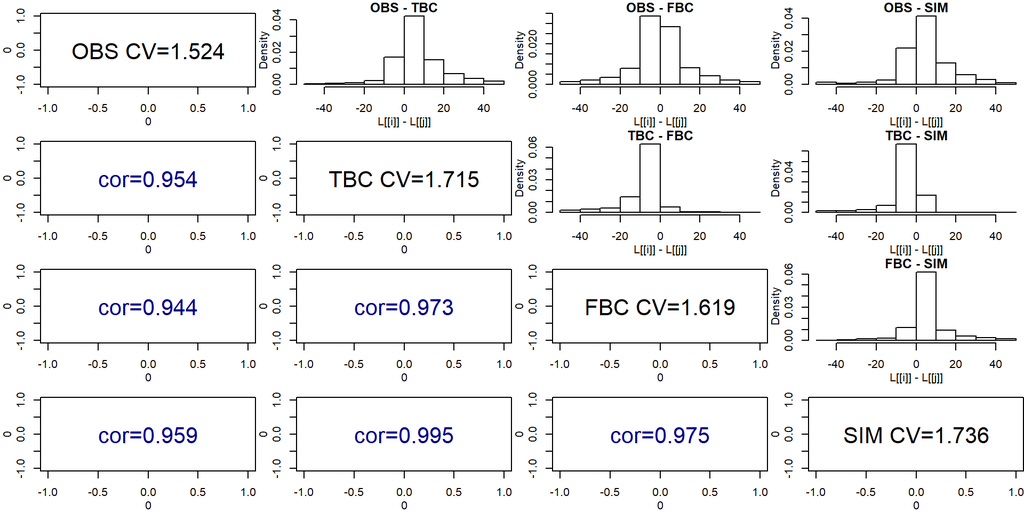

```r
qmed_TBC <- am_glo_TBC %>% dplyr::filter(rcm==1) %>% dplyr::select(QMED)
qmed_FBC <- am_glo_FBC %>% dplyr::filter(rcm==1) %>% dplyr::select(QMED)
qmed_obs <- am_glo_obs %>% dplyr::select(QMED)
qmed_sim <- am_glo_simobs %>% dplyr::select(QMED)

nams <- c("OBS", "TBC", "FBC", "SIM")
L <- list(unlist(qmed_obs, use.names=F),
          unlist(qmed_TBC, use.names=F),
          unlist(qmed_FBC, use.names=F),
          unlist(qmed_sim, use.names=F))

par(mar=c(3,3,1,0), mgp=c(2,1,0), mfrow=c(4,4))

for(i in 1:4){
  for(j in 1:4){
    if(i==j){
      plot(0,0, xlim=c(-1,1), ylim=c(-1,1), pch=NA)
      text(0,0,labels=paste0(nams[i], " CV=",
                             round(sd(L[[i]], na.rm=T)/mean(L[[i]], na.rm=T),3)),
           cex=2)    #check sd, mean and cor
    }else if(i < j){
      hist(L[[i]] - L[[j]],
           breaks=c(-Inf,-50,-40,-30,-20,-10,0,10,20,30,40,50,Inf),
           xlim=c(-50,50),
           main=paste(nams[i], "-", nams[j]))
    }else{
      plot(0,0, xlim=c(-1,1), ylim=c(-1,1), pch=NA)
      text(0,0,labels=paste0("cor=",round(cor(L[[i]],L[[j]]),3)), cex=2, col="darkblue")
    }
  }
}
```

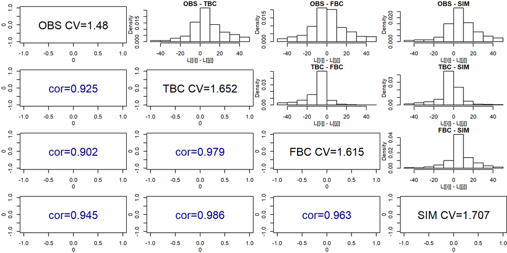

```r
q20_TBC <- am_glo_TBC %>% dplyr::filter(rcm==1) %>% dplyr::select(Q20)
q20_FBC <- am_glo_FBC %>% dplyr::filter(rcm==1) %>% dplyr::select(Q20)
q20_obs <- am_glo_obs %>% dplyr::select(Q20)
q20_sim <- am_glo_simobs %>% dplyr::select(Q20)

L <- list(unlist(q20_obs, use.names=F),
          unlist(q20_TBC, use.names=F),
          unlist(q20_FBC, use.names=F),
          unlist(q20_sim, use.names=F))

par(mar=c(3,3,1,0), mgp=c(2,1,0), mfrow=c(4,4))

for(i in 1:4){
  for(j in 1:4){
    if(i==j){
      plot(0,0, xlim=c(-1,1), ylim=c(-1,1), pch=NA)
      text(0,0,labels=paste0(nams[i],
                             " CV=",
                             round(sd(L[[i]], na.rm=T)/mean(L[[i]], na.rm=T),3)),
           cex=2)    #check sd, mean and cor
    }else if(i < j){
      hist(L[[i]] - L[[j]],
           breaks=c(-Inf,-50,-40,-30,-20,-10,0,10,20,30,40,50,Inf),
           xlim=c(-50,50),
           main=paste(nams[i], "-", nams[j]))
    }else{
      plot(0,0, xlim=c(-1,1), ylim=c(-1,1), pch=NA)
      text(0,0,labels=paste0("cor=",round(cor(L[[i]],L[[j]]),digits=3)), cex=2, col="darkblue")
    }
  }
}
```

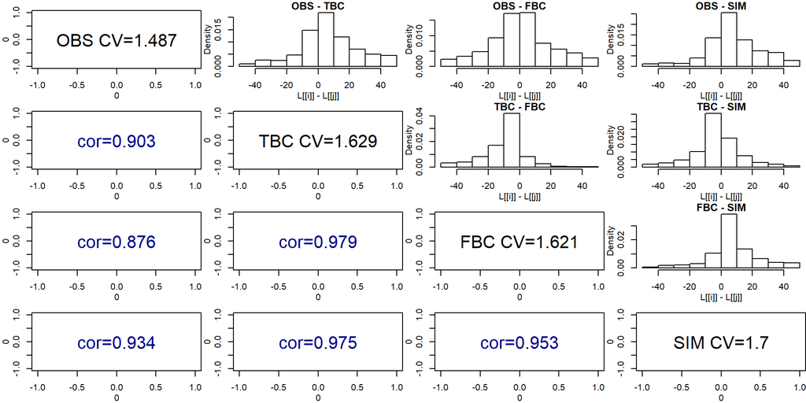

```r
q50_TBC <- am_glo_TBC %>% dplyr::filter(rcm==1) %>% dplyr::select(Q50)
q50_FBC <- am_glo_FBC %>% dplyr::filter(rcm==1) %>% dplyr::select(Q50)
q50_obs <- am_glo_obs %>% dplyr::select(Q50)
q50_sim <- am_glo_simobs %>% dplyr::select(Q50)
L <- list(unlist(q50_obs, use.names=F),
          unlist(q50_TBC, use.names=F),
          unlist(q50_FBC, use.names=F),
          unlist(q50_sim, use.names=F))

par(mar=c(3,3,1,0), mgp=c(2,1,0), mfrow=c(4,4))

for(i in 1:4){
  for(j in 1:4){
    if(i==j){
      plot(0,0, xlim=c(-1,1), ylim=c(-1,1), pch=NA)
      text(0,0,labels=paste0(nams[i], " CV=",
                             round(sd(L[[i]], na.rm=T)/mean(L[[i]], na.rm=T),digits=3)),
           cex=2)    #check sd, mean and cor
    }else if(i < j){
      hist(L[[i]] - L[[j]],
           breaks=c(-Inf,-50,-40,-30,-20,-10,0,10,20,30,40,50,Inf),
           xlim=c(-50,50),
           main=paste(nams[i], "-", nams[j]))
    }else{
      plot(0,0, xlim=c(-1,1), ylim=c(-1,1), pch=NA)
      text(0,0,labels=paste0("cor=",round(cor(L[[i]],L[[j]]),digits=3)), cex=2, col="darkblue")
    }
  }
}
```

### Example comparing between ensemble members

We use 76005 on the Eden as an example. We compare the DM AMAX values for QMED, Q20 and Q50 (fitted to GLO via L-moments methods) across all 12 ensemble members.

```r
stn0 <- 76005 #39001

tbc_line <- am_glo_TBC %>% dplyr::filter(station==stn0) %>% select(QMED) %>% unlist(.)
fbc_line <- am_glo_FBC %>% dplyr::filter(station==stn0) %>% select(QMED) %>% unlist(.)
obs_line <- am_glo_obs %>% dplyr::filter(station==stn0) %>% select(QMED) %>% unlist(.)
sim_line <- am_glo_simobs %>% dplyr::filter(station==stn0) %>% select(QMED) %>% unlist(.)

tbc_line20 <- am_glo_TBC %>% dplyr::filter(station==stn0) %>% select(Q20) %>% unlist(.)
fbc_line20 <- am_glo_FBC %>% dplyr::filter(station==stn0) %>% select(Q20) %>% unlist(.)
obs_line20 <- am_glo_obs %>% dplyr::filter(station==stn0) %>% select(Q20) %>% unlist(.)
sim_line20 <- am_glo_simobs %>% dplyr::filter(station==stn0) %>% select(Q20) %>% unlist(.)

tbc_line50 <- am_glo_TBC %>% dplyr::filter(station==stn0) %>% select(Q50) %>% unlist(.)
fbc_line50 <- am_glo_FBC %>% dplyr::filter(station==stn0) %>% select(Q50) %>% unlist(.)
obs_line50 <- am_glo_obs %>% dplyr::filter(station==stn0) %>% select(Q50) %>% unlist(.)
sim_line50 <- am_glo_simobs %>% dplyr::filter(station==stn0) %>% select(Q50) %>% unlist(.)

#range(sim_line50)
print((sim_line50 - obs_line50)/obs_line50)
```

```
##        Q50
## -0.3489005
```

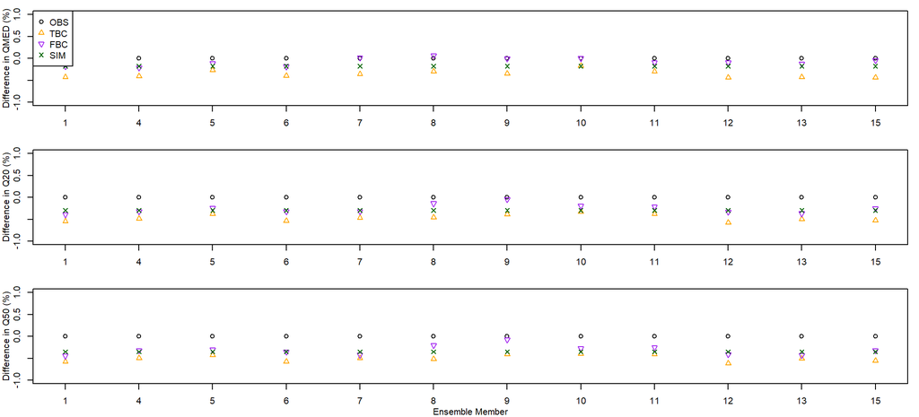

```r
# Plot of relative difference in QMED, Q20 and Q50 on average between RCMs

#png("./kingston.png", width=160, height=100, units='mm', res=300, pointsize=11)
par(mar=c(3,3,1,1), mgp=c(2,1,0), mfrow=c(3,1))

plot(1:length(rcm_nos), rep(0,length(rcm_nos)), pch=1, col="black",
     xaxt='n', xlab="", ylab="Difference in QMED (%)", ylim=c(-1,1))
points(1:length(rcm_nos), (tbc_line-obs_line)/obs_line, col="orange", pch=2)
points(1:length(rcm_nos), (fbc_line-obs_line)/obs_line, col="purple", pch=6)
points(1:length(rcm_nos), rep((sim_line-obs_line)/obs_line, length(rcm_nos)),
       col="darkgreen", pch=4)
axis(1, at=1:length(rcm_nos), labels=rcm_nos)
legend("topleft", legend=c("OBS", "TBC", "FBC", "SIM"),
       col=c("black", "orange", "purple", "darkgreen"), pch=c(1,2,6,4))

plot(1:length(rcm_nos), rep(0,length(rcm_nos)), pch=1, col="black",
     xaxt='n', xlab="", ylab="Difference in Q20 (%)", ylim=c(-1,1))
points(1:length(rcm_nos), (tbc_line20-obs_line20)/obs_line20, col="orange", pch=2)
points(1:length(rcm_nos), (fbc_line20-obs_line20)/obs_line20, col="purple", pch=6)
points(1:length(rcm_nos), rep((sim_line20-obs_line20)/obs_line20, length(rcm_nos)),
       col="darkgreen", pch=4)
axis(1, at=1:length(rcm_nos), labels=rcm_nos)

plot(1:length(rcm_nos), rep(0,length(rcm_nos)), pch=1, col="black",
     xaxt='n', xlab="Ensemble Member", ylab="Difference in Q50 (%)", ylim=c(-1,1))
points(1:length(rcm_nos), (tbc_line50-obs_line50)/obs_line50, col="orange", pch=2)
points(1:length(rcm_nos), (fbc_line50-obs_line50)/obs_line50, col="purple", pch=6)
points(1:length(rcm_nos), rep((sim_line50-obs_line50)/obs_line50, length(rcm_nos)),
       col="darkgreen", pch=4)
axis(1, at=1:length(rcm_nos), labels=rcm_nos)
```

[output not shown]

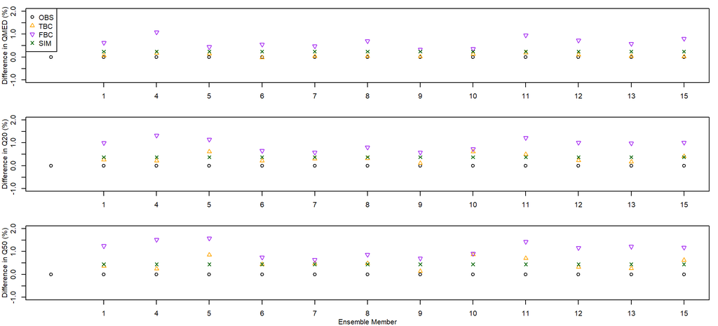

```r
#dev.off()

png("./eden2.png", width=160, height=100, units='mm', res=300, pointsize=11)
par(mar=c(3,3,1,1), mgp=c(2,1,0), mfrow=c(3,1))

plot(0:length(rcm_nos), rep(0,length(rcm_nos)+1), pch=1, col="black",
     xaxt='n', xlab="", ylab="Difference in QMED (%)", ylim=c(-1,1))
points(1:length(rcm_nos), (tbc_line-obs_line)/obs_line, col="orange", pch=2)
points(1:length(rcm_nos), (fbc_line-obs_line)/obs_line, col="purple", pch=6)
points(1:length(rcm_nos), rep((sim_line-obs_line)/obs_line, length(rcm_nos)),
       col="darkgreen", pch=4)
axis(1, at=1:length(rcm_nos), labels=rcm_nos)
legend("topleft", legend=c("OBS", "TBC", "FBC", "SIM"),
       col=c("black", "orange", "purple", "darkgreen"), pch=c(1,2,6,4))

plot(0:length(rcm_nos), rep(0,length(rcm_nos)+1), pch=1, col="black",
     xaxt='n', xlab="", ylab="Difference in Q20 (%)", ylim=c(-1,1))
points(1:length(rcm_nos), (tbc_line20-obs_line20)/obs_line20, col="orange", pch=2)
points(1:length(rcm_nos), (fbc_line20-obs_line20)/obs_line20, col="purple", pch=6)
points(1:length(rcm_nos), rep((sim_line20-obs_line20)/obs_line20, length(rcm_nos)),
       col="darkgreen", pch=4)
axis(1, at=1:length(rcm_nos), labels=rcm_nos)

plot(0:length(rcm_nos), rep(0,length(rcm_nos)+1), pch=1, col="black",
     xaxt='n', xlab="Ensemble Member", ylab="Difference in Q50 (%)", ylim=c(-1,1))
points(1:length(rcm_nos), (tbc_line50-obs_line50)/obs_line50, col="orange", pch=2)
points(1:length(rcm_nos), (fbc_line50-obs_line50)/obs_line50, col="purple", pch=6)
points(1:length(rcm_nos), rep((sim_line50-obs_line50)/obs_line50, length(rcm_nos)),
       col="darkgreen", pch=4)
axis(1, at=1:length(rcm_nos), labels=rcm_nos)
dev.off()
```

This plot shows percentage difference in QMED, Q20 and Q50, with observed as a black circle (always zero), with bias correction in orange, and without in purple. This again highlights the negative bias in nearly all the ensemble members, but that there are differences between them. On the whole, the use of bias correction actually increases underestimation compared to mean daily flow.

### Time series comparison

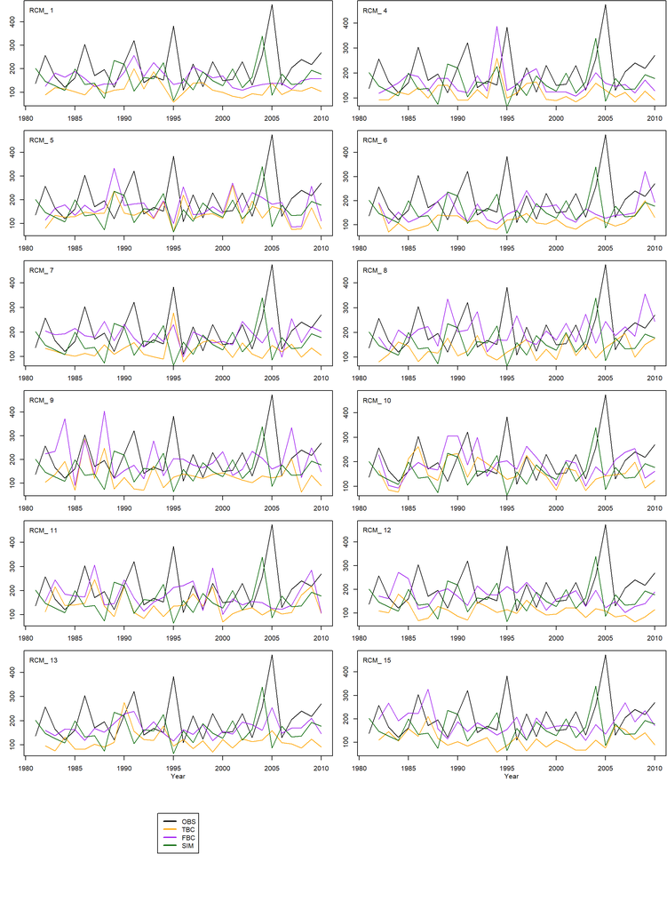

```r
am_obs1 <- am_summ_obs %>% dplyr::filter(station==76005) %>% select(year, value)
am_sim1 <- am_sim_obs %>% dplyr::filter(station==76005) %>% select(year, value)
# Comparison of like-for-like time series
par(mar=c(3,3,0.1,0.1), mgp=c(2,1,0), mfrow=c(7,2))
for(i in 1:length(rcm_nos)){
  am_tbc1 <- am_summ_TBC %>% dplyr::filter(station==76005 & rcm==rcm_nos[i]) %>% select(year, value)
  am_fbc1 <- am_summ_FBC %>% dplyr::filter(station==76005 & rcm==rcm_nos[i]) %>% select(year, value)

  plot(am_obs1$year, am_obs1$value, col=1, type='l', xlab=ifelse(i>10,"Year",""),
       ylab="", ylim=range(am_tbc1$value, am_fbc1$value, am_obs1$value, na.rm=T))
  lines(am_tbc1$year, am_tbc1$value, col="orange")
  lines(am_fbc1$year, am_fbc1$value, col="purple")
  lines(am_sim1$year, am_sim1$value, col="darkgreen")
  text(1980,450,labels=paste("RCM_", rcm_nos[i]), pos=4)
}

plot(0,0, xlim=c(-1,1), ylim=c(-1,1), xaxt="n", yaxt="n", axes=F, xlab="", ylab="")
legend("center", legend=c("OBS","TBC", "FBC", "SIM"), col=c("black", "orange", "purple", "darkgreen"),
       lwd=2, border=NA)
```

Here are the time series for the twelve different ensemble members for station 76005 (Eden). One can see that on average, the time series match reasonably, the 1995 and 2005 calues are much higher in observed than any value in the modelled values. This may explain the underestimation in QT.

### Maps

```r
par(mar=c(0.5,0.5,0.5,0.5), mgp=c(2,1,0))
uk_outline <- readOGR("C:/Users/adagri/Documents/ResilRiskInds_C/interim_data/uk_outline")
qmed_TBC <- am_glo_TBC %>% group_by(station) %>% summarise(qmed_av=mean(QMED))
qmed_FBC <- am_glo_FBC %>% group_by(station) %>% summarise(qmed_av=mean(QMED))
qmed_obs <- am_glo_obs %>% dplyr::select(station, QMED)
qmed_sim <- am_glo_simobs %>% dplyr::select(station, QMED)

posUK <- CATAL %>% dplyr::filter(id %in% qmed_TBC$station) %>% dplyr::select(id, easting, northing)

Qpc <- (qmed_TBC$qmed_av - qmed_obs$QMED)/qmed_obs$QMED#
summary(Qpc)
```

```
##      Min.   1st Qu.    Median      Mean   3rd Qu.      Max.
## -0.933789 -0.360077 -0.211206 -0.089853  0.008117 10.822835
```

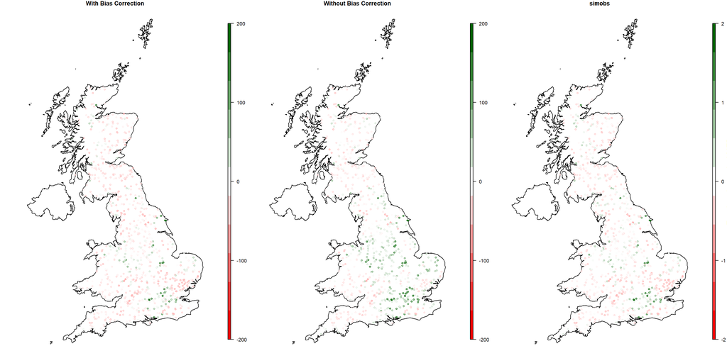

```r
Qpc[Qpc > 2] <- 2
Qpc[Qpc < -2] <- -2

Qpc2 <- (Qpc + 2)/4

r2g <- colorRamp(c("red", "white", "darkgreen"))
r2g2 <- colorRampPalette(c("red", "white", "darkgreen"))(11)

f <- function(){
par(mfrow=c(1,3), mar=c(1,1,1,3), mgp=c(2,1,0))
plot(uk_outline, main="With Bias Correction")
points(posUK$easting, posUK$northing, cex=0.7, col=rgb(r2g(Qpc2), maxColorValue=256))
image.plot(Qpc2, add=T, breaks=seq(from=-200,to=200,length.out=12), col=r2g2,
           legend.only=T)

Qpc <- (qmed_FBC$qmed_av - qmed_obs$QMED)/qmed_obs$QMED
summary(Qpc)
Qpc[Qpc > 2] <- 2
Qpc[Qpc < -2] <- -2

Qpc2 <- (Qpc + 2)/4

plot(uk_outline,  main="Without Bias Correction")
points(posUK$easting, posUK$northing, cex=0.7, col=rgb(r2g(Qpc2), maxColorValue=256))
image.plot(Qpc2, add=T, breaks=seq(from=-200,to=200,length.out=12), col=r2g2,
           legend.only=T)

Qpc <- (qmed_sim$QMED - qmed_obs$QMED)/qmed_obs$QMED
summary(Qpc)
Qpc[Qpc > 2] <- 2
Qpc[Qpc < -2] <- -2

Qpc2 <- (Qpc + 2)/4

plot(uk_outline,  main="simobs")
points(posUK$easting, posUK$northing, cex=0.7, col=rgb(r2g(Qpc2), maxColorValue=256))
image.plot(Qpc2, add=T, breaks=seq(from=-2,to=2,length.out=12), col=r2g2,
           legend.only=T, legend.lab="Fraction change in QMED")
}
f()
```

```
##     Min.  1st Qu.   Median     Mean  3rd Qu.     Max.
## -0.95806 -0.37585 -0.20603 -0.07481  0.07897  8.04328
```

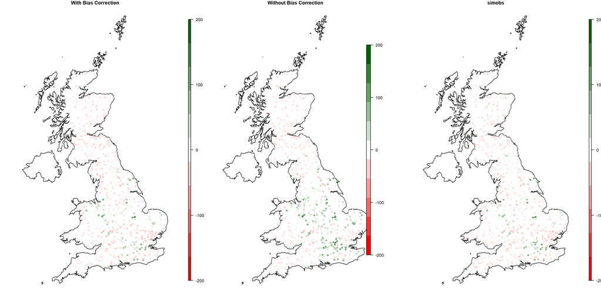

```
##     Min.  1st Qu.   Median     Mean  3rd Qu.     Max.
## -0.96273 -0.38708 -0.17732 -0.02987  0.15766  7.24737
```

[figure not shown]

```r
png("./MapsQMED.png", width=160, height=90, units='mm', res=300, pointsize=10)
f()
dev.off()
```

## Conclusions

Given this limited investigation, it seems that the bias correction will give less accurate flood frequency estimates compared to observed records.

## References

Guillod, B.P., Jones, R.G., Dadson, S.J., Coxon, G., Bussi, G., Freer, J. & Allen, M.R. (2018). A large set of potential past, present and future hydro-meteorological time series for the UK. Hydrology and Earth System Sciences, 22(1), 611-634.